# XX_Analyze genomic data

# 5 PCA and clustering

## 5.1 PCA

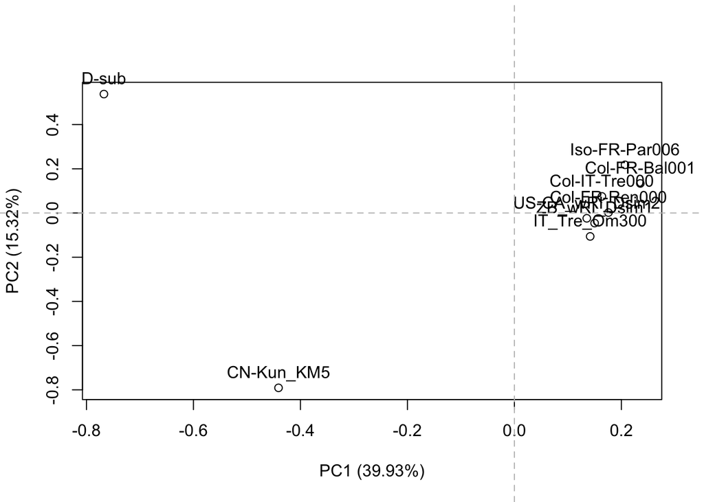

```r
set.seed(1234)
par(xpd=TRUE)
res.pca <- poolfstat::randomallele.pca(x = wSuz.pooldata, plot.pcs = c(1, 2), return.snploadings = TRUE)
```

## 5.2 Clustering of variants

```r
fstats <- poolfstat::compute.fstats(x=wSuz.pooldata, output.pairwise.div = TRUE, verbose = TRUE, computeF3 = FALSE, computeF4 = FALSE)
```

```
Estimating Q1
Estimating Q2
Estimating within-population heterozygosities
Estimating F2, pairwise Fst (method=Identity), and pairwise divergence (1-Q2)

Overall Analysis Time: 0 h 0 m 0 s
```

```r
## Export divergence
fstats@pairwise.div
```

```
                CN-Kun_KM5 Col-FR-Bal001 Col-FR-Ren000 Col-IT-Tre000      D-sub
CN-Kun_KM5      0.00000000    0.09584110    0.09455285    0.09894491 0.06052136
Col-FR-Bal001   0.09584110    0.00000000    0.05318230    0.05232458 0.11511726
Col-FR-Ren000   0.09455285    0.05318230    0.00000000    0.05593577 0.11577076
Col-IT-Tre000   0.09894491    0.05232458    0.05593577    0.00000000 0.11554550
D-sub           0.06052136    0.11511726    0.11577076    0.11554550 0.00000000
Iso-FR-Par006   0.09918521    0.05216851    0.05620838    0.05294018 0.11560716
IT_Tre_Om300    0.07962150    0.04123996    0.04080570    0.04434966 0.10129616
US-CA_wRI_Dsim2 0.08034937    0.04487279    0.04379350    0.04659016 0.09707902
ZB_wRI_Dsim1    0.07471407    0.03933319    0.03584386    0.04231093 0.09553639
                Iso-FR-Par006 IT_Tre_Om300 US-CA_wRI_Dsim2 ZB_wRI_Dsim1
CN-Kun_KM5         0.09918521   0.07962150      0.08034937   0.07471407
Col-FR-Bal001      0.05216851   0.04123996      0.04487279   0.03933319
Col-FR-Ren000      0.05620838   0.04080570      0.04379350   0.03584386
Col-IT-Tre000      0.05294018   0.04434966      0.04659016   0.04231093
D-sub              0.11560716   0.10129616      0.09707902   0.09553639
Iso-FR-Par006      0.00000000   0.04501442      0.04662797   0.04289329
IT_Tre_Om300       0.04501442   0.00000000      0.03099619   0.02204577
US-CA_wRI_Dsim2    0.04662797   0.03099619      0.00000000   0.01196782
ZB_wRI_Dsim1       0.04289329   0.02204577      0.01196782   0.00000000
```

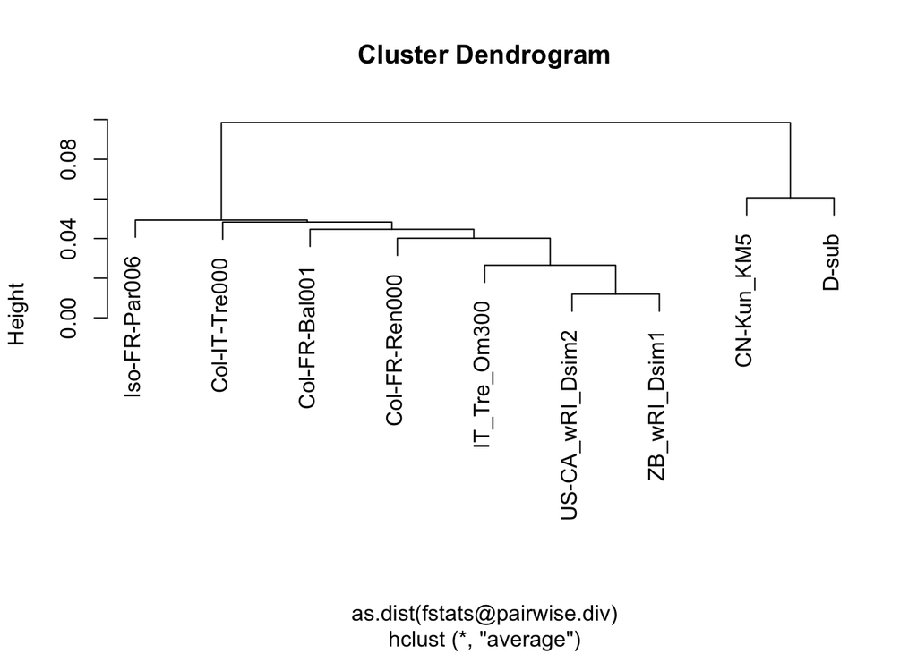

```r
## Hirarchical clustering equivalent to UPGMA
tt <- hclust(as.dist(fstats@pairwise.div), method= "average")
plot(tt)
```

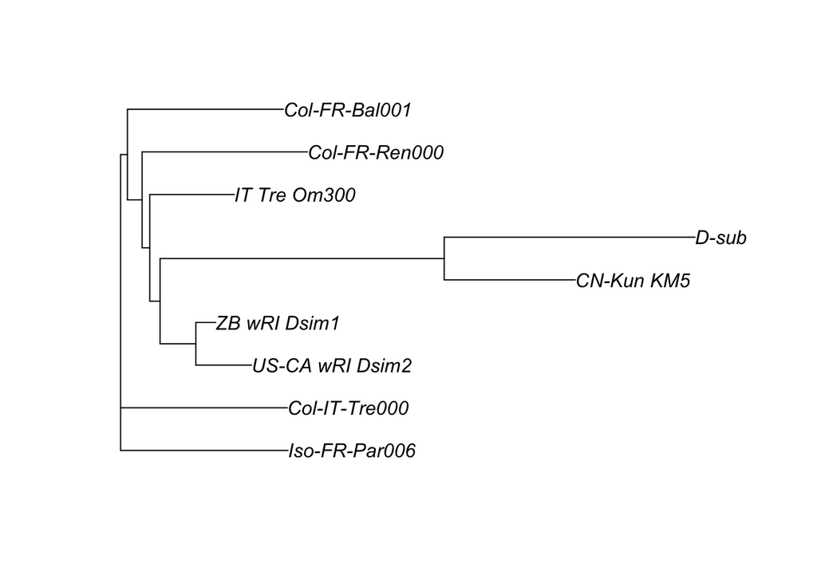

```r
## Neighbor joining distance
tt <- ape::nj(as.dist(fstats@pairwise.div))
plot(tt)
```

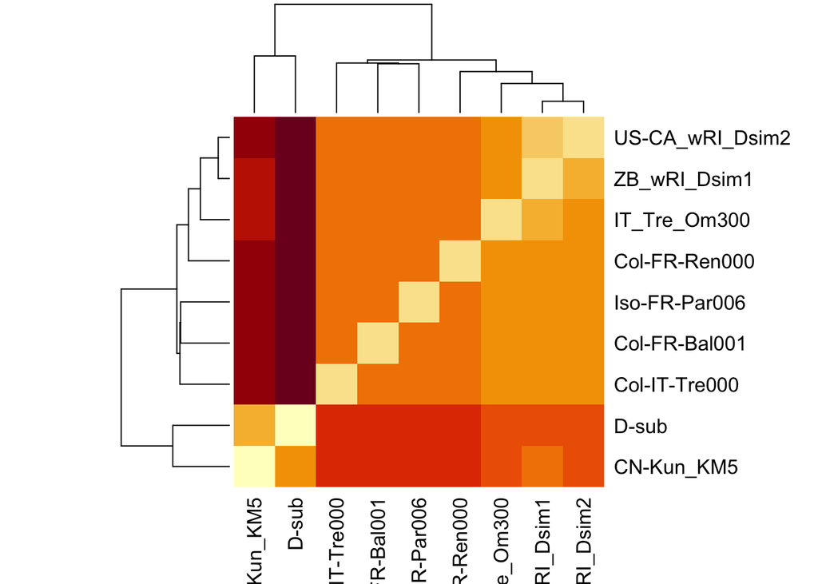

```r
#quartz()
## Heatmap
heatmap(fstats@pairwise.div, distfun = as.dist)
```

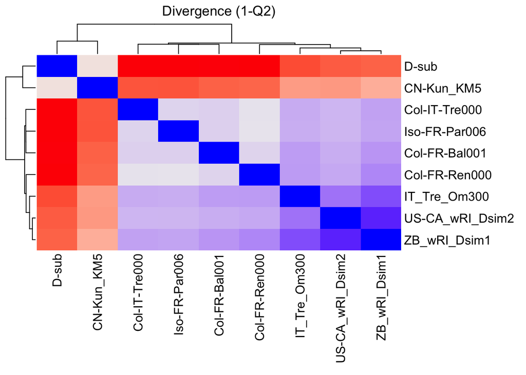

```r
## With ComplexHeatmap
div.hm <- ComplexHeatmap::Heatmap(fstats@pairwise.div,
cluster_rows =TRUE,cluster_columns=TRUE,name="Divergence",
show_heatmap_legend=FALSE,column_title = "Divergence (1-Q2)")

div.hm
```

# 6 Cif genes TODO Sveta (please check that there is no coverage information in the second copy of WO-B at position 1,071,000 to 1,142,000)

Conner et al 2017 wRi, there are two nearly identical copies (99.4%) of WO-B, from about 565,000 : 636,000 and from about 1,071,000 to 1,142,000 https://www.genome.jp/dbget-bin/www_bget?refseq+NC_012416

Type I cifA WRI_RS02675 WRi_005370 in wRI 571723:573147 cifB WRI_RS07690 WRi_p05380 in WRI: 573223:576723 (stop codon in wRI)

Type I cifA WRI_RS05040 WRi_010030 in wRI 1078182:1079606 cifB WRI_RS07735 WRi_p10040 in WRI: 1079682:1083182 (stop codon in wRI)

Type II cifA WRI_RS03370 WRi_006720 in wRI 728237:729607 (partial with insertion at 729284 in wSuz) cifB WRI_RS03365 WRi_006710 in WRI: 725963:728227

```r
## Thoughts on the lack of CI:
## 5 mutations in Type I cifB between wSuz and wMel (some of them shared with wSuz)
## inactivation of Type II cifA by a transposase in wSuz and wSpc but not in wRI (Conner et al 2017)

data <- read.table(file=here::here("data/derived_data/wol_genotypes.csv"), sep=";", header = TRUE)
```